# R for Data Science - Final exam

Caterina Daidone, Paola Galfrascoli, Anastasia Galkina, Muhammad Haroon Shaukat

2023-04-28

## Exercise 1 - Exploratory Data Analysis

**Who sent the highest number of messages?**  
Andrea Gilardi sent the highest number of messages: 233.

```r
covfefe_chat %>%  count(author, sort = T)
```

```
## # A tibble: 32 × 2
##    author                    n
##    <fct>                 <int>
##  1 Andrea Gilardi          233
##  2 Chiara Magnani          192
##  3 Laura D'Angelo          190
##  4 Giorgia Zaccaria        186
##  5 Luca Aiello             181
##  6 Tommaso Rigon           146
##  7 Claudia Sartirana        85
##  8 Valentina Zangirolami    76
##  9 Roberto Ascari           72
## 10 Luca Danese              47
## # … with 22 more rows
```

**How many messages were exchanged during December 2022?**  
During December 2022 were exchanged 246 messages.

```r
covfefe_chat %>%
  mutate(Month = lubridate::month(time, label = FALSE),
         Year = lubridate::year(time), DayMonth = format(as.Date(time), "%y-%m")) %>%
  count(DayMonth) %>%  filter(DayMonth == '22-12')
```

```
## # A tibble: 1 × 2
##   DayMonth     n
##   <chr>    <int>
## 1 22-12      246
```

**Who sent the first message of the current year? At which time?**  
The first message of the 2023 was sent by Andrea Gilardi at 15:08 on 2023-01-04.

```r
covfefe_chat %>% filter(time > '2022-12-31') %>%  slice(1)
```

```
## # A tibble: 1 × 6
##   time                author         text                   source emoji emoji…¹
##   <dttm>              <fct>          <chr>                  <chr>  <lis> <list>
## 1 2023-01-04 15:08:11 Andrea Gilardi "Hi everyone! First o… C:/! … <chr> <chr>
## # … with abbreviated variable name ¹emoji_name
```

**On which day did we exchange the highest number of messages? After filtering the corresponding text messages, check their content and try to explain the anomalous behaviour.**  
The highest number of messages was exchanged on the 1st February 2023 (60 messages).

```r
covfefe_chat %>%
  mutate(YearMonthDay = format(as.Date(time), "%y-%m-%d")) %>% count(YearMonthDay, sort = T)
```

```
## # A tibble: 111 × 2
##    YearMonthDay     n
##    <chr>        <int>
##  1 23-02-01        60
##  2 22-12-06        53
##  3 22-11-11        38
##  4 23-03-02        38
##  5 22-10-28        34
##  6 22-10-27        31
##  7 22-11-04        29
##  8 22-12-05        29
##  9 22-12-14        29
## 10 22-11-02        28
## # … with 101 more rows
```

Most of the messages of this day were exchanged to plan for an aperitif in the evening and a poll was created to count how many people were in. There were difficulties in finding a place where to have it.

```r
covfefe_chat %>%
  mutate(YearMonthDay = format(as.Date(time), "%y-%m-%d")) %>%
  filter(YearMonthDay == "23-02-01") %>% select(text)
```

```
## # A tibble: 60 × 1
##    text
##    <chr>
##  1 "I’m in!"
##  2 "I'm in loaded as a spring"
##  3 "Lunch in 15?"
##  4 "Yeah"
##  5 "First year office?"
##  6 "Tooop!"
##  7 "Or outside in the sun?"
##  8 "It's warm today"
##  9 "Seriously?\U0001f92a"
## 10 "Second year wants to stay warm inside\U0001f607"
## # … with 50 more rows
```

**How many messages are sent on average per day?**  
15 messages are sent on average per day.

```r
covfefe_chat %>%
  mutate(YearMonthDay = format(as.Date(time), "%y-%m-%d")) %>%
  count(YearMonthDay) %>% summarise(mean = mean(as.numeric(n))) %>% round()
```

```
## # A tibble: 1 × 1
##    mean
##   <dbl>
## 1    15
```

**Who sent the highest number of messages which included at least one emoji?**  
Andrea Gilardi sent the highest number of messages (66) which included at least one emoji.

```r
covfefe_chat %>% filter(!vapply(emoji, is.null, logical(1))) %>% count(author, sort = T)
```

```
## # A tibble: 23 × 2
##    author                  n
##    <fct>               <int>
##  1 Andrea Gilardi         66
##  2 Giorgia Zaccaria       62
##  3 Chiara Magnani         43
##  4 Claudia Sartirana      42
##  5 Tommaso Rigon          19
##  6 Ludovica De Carolis    14
##  7 Roberto Ascari         13
##  8 Muhammad Amir Saeed     9
##  9 Jiefeng Bi              8
## 10 Luca Presicce           8
## # … with 13 more rows
```

```r
library(tidyr)

covfefe_chat%>%
  unnest(c(emoji,emoji_name))%>%
  filter(!is.na(author)& emoji!="NULL")%>%
  group_by(author,emoji)%>%
  reframe(emoji,emoji_name,freq=n())%>%
  group_by(author) %>%
  arrange(desc(freq), .by_group = T) %>%
  distinct() %>%
  slice_head()
```

```
## # A tibble: 23 × 4
## # Groups:   author [23]
##    author               emoji                  emoji_name                   freq
##    <fct>                <chr>                  <chr>                       <int>
##  1 Alessandro Colombi   "\U0001f44b\U0001f3fb" waving hand: light skin to…     2
##  2 Alessia Caponera     "\U0001f604"           grinning face with smiling…     1
##  3 Alice Giampino       "\U0001f601"           beaming face with smiling …     2
##  4 Andrea Gilardi       "☕"                   hot beverage                   18
##  5 Caterina Daidone     "\U0001f973"           partying face                   2
##  6 Chiara Magnani       "\U0001f44d\U0001f3fb" thumbs up: light skin tone      8
##  7 Claudia Sartirana    "\U0001f602"           face with tears of joy         11
##  8 Federico Camerlenghi "\U0001f62c"           grimacing face                  3
##  9 Federico Cortese     "⚰️"                    coffin                          1
## 10 Francesco Barile     "✋"                   raised hand                     1
## # … with 13 more rows
```

**Compute and display the total number of messages exchanged in the whatsapp chat after dividing the observations according to the hour of the day AND the day of the week**

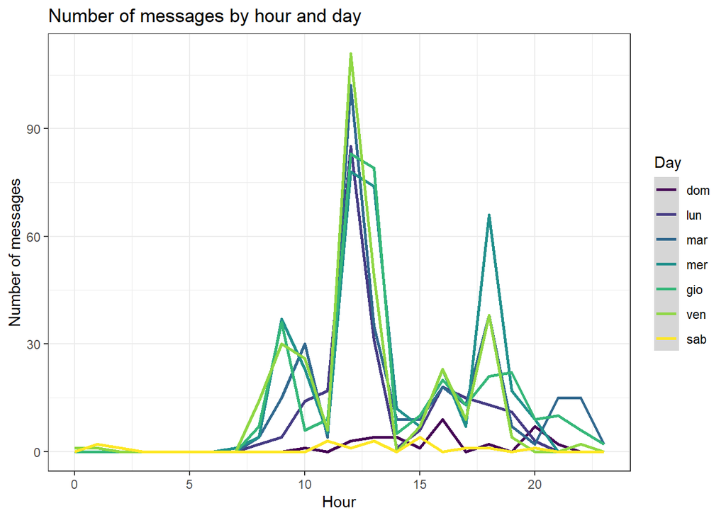

```r
library(lubridate)

df_plot<-covfefe_chat%>%
  complete(time= seq.POSIXt(min(time), max(time), by="hour"))%>%
  group_by(Day=wday(time,label = T), Hour=hour(time))%>%
    reframe(Freq_text=sum(table(text)))%>%
  select(Day, Hour, Freq_text)

library(ggplot2)
library(ggrepel)
df_plot%>%
ggplot(aes(x= Hour, y=Freq_text))+
   geom_smooth(aes(color = Day),show.legend = T, stat="identity")+
   labs(x ="Hour" , y="Number of messages" , title = "Number of messages by hour and day")+
     theme_bw()
```

## Exercise 2 - Debugging techniques

**Question 1: Explain why `termplot()` raises a warning message when we pass `mod2` instead of `mod1` and the steps you took / the techniques you used to tackle this problem.**

First, we run the code provided in the text to create the data of the example and we investigates the output of the `termplot()` function.

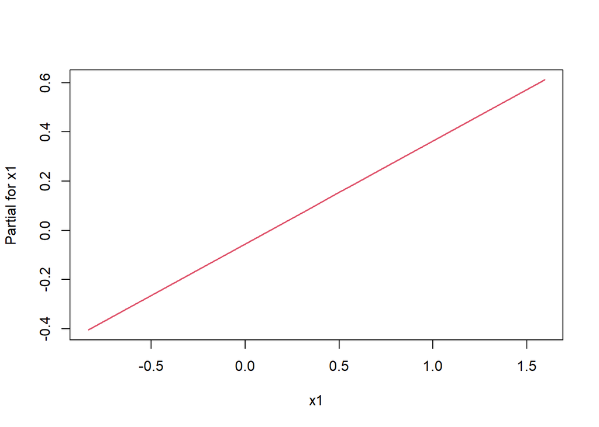

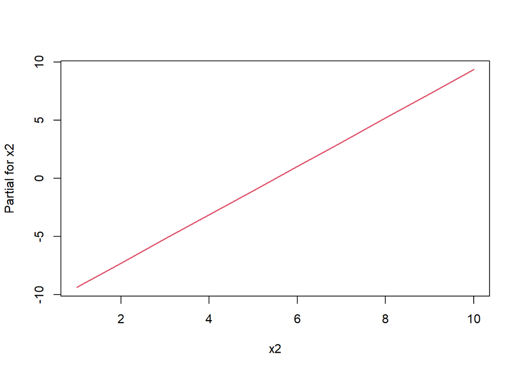

```r
set.seed(1)
n <- 10L
x1 <- rnorm(n)
x2 <- seq.int(n)
beta0 <- 0; beta1 <- 1; beta2 <- 2
y <- beta0 + beta1 * x1 + beta2 * x2 + rnorm(n)

(mod1 <- lm(y ~ x1 + x2))
termplot(mod1, ask = FALSE, ylim = "free")
```

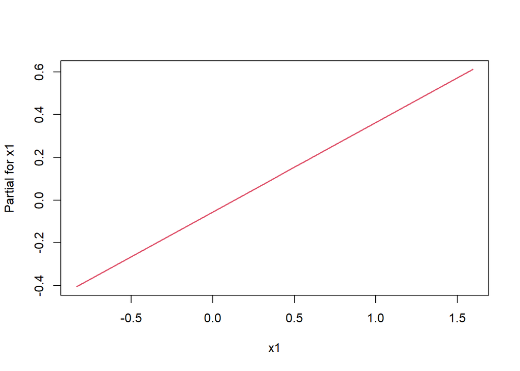

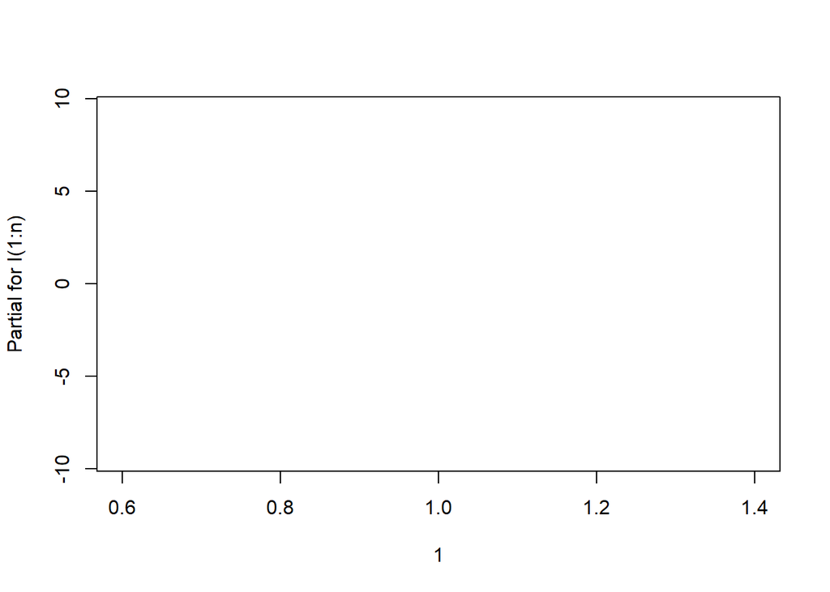

```r
(mod2 <- lm(y ~ x1 + I(1:n)))
termplot(mod2, ask = FALSE, ylim = "free")
```

Then, in order to understand how the function works, we go into the debug mode. Since the `termplot()` function is defined in a base package (`stats`), we cannot use the `browser()` call directly into the function definition. Then, we use the `debug()` function that automatically sets up a `browser()` call at the beginning of the `termplot()` function. (We will not print the entire debug console output for conciseness.)

```r
debug(termplot)
termplot(mod2, ask = FALSE, ylim = "free")
```

```
## Warning in termplot(mod2, ask = FALSE, ylim = "free"): 'model' appears to
## involve interactions: see the help page
```

In debug mode, we go through the function code using the following debug commands:  
`n`: executes the next step in the function;  
`s`: steps into the next function;  
`f`: finishes execution of the current loop or function;  
`c`: leaves interactive debugging and continues regular execution of the function;  
`q`: stops debugging, terminates the function, and returns to the global workspace.

The warning message appears because of the following piece of code:

```r
if (any(grepl(":", nmt, fixed = TRUE)))
        warning("'model' appears to involve interactions: see the help page",
            domain = NA, immediate. = TRUE)
```

The function `grepl()` identifies the symbol “:” in the object `nmt`, which is the vector of column names of the output of the `predict()` function applied to `mod2` inside `termplot()`. If there are interactions in the model, some of the column names will have the “:” in them (e.g. an interaction between `x1` and `x2` will have its corresponding column name as `x1:x2`). So, this code is intended to create a warning when there are some interactions in the model, but in our case it appears because in `mod2` the second variable is expressed as `I(1:n)`.

**Question 2: Explain why `termplot()` creates an empty plot when displaying the relationship between `x2 := 1:n` and its predicted values.**

When selecting the $x$-axis values for the plot, the `termplot()` function adopts a procedure that erroneously picks just the value $1$. More in detail, the function that selects the $x$-axis values is the `carrier()` function, defined inside the `termplot()` itself. Then, by using command `s` in debug mode, we step into this function and see why the code doesn’t work for the variable named `I(1:n)`. This function has arguments `term` and `transform`. The second term is equal `FALSE` in our example, while the first one is taken from an object of the form `expression(x1, I(1:n))`, obtained by applying the function `str2expression()` to the column names `x1` and `I(1:n)`. Because of an `if` condition that evaluates the length of the argument `term` being greater than `1L`, the function, after some repeated steps, returns as the $x$-axis values as single number: $1$. The `xlim` argument and the $y$-axis values of the plot are also affected by this result, and the consequence is a plot similar to the output of the following code:

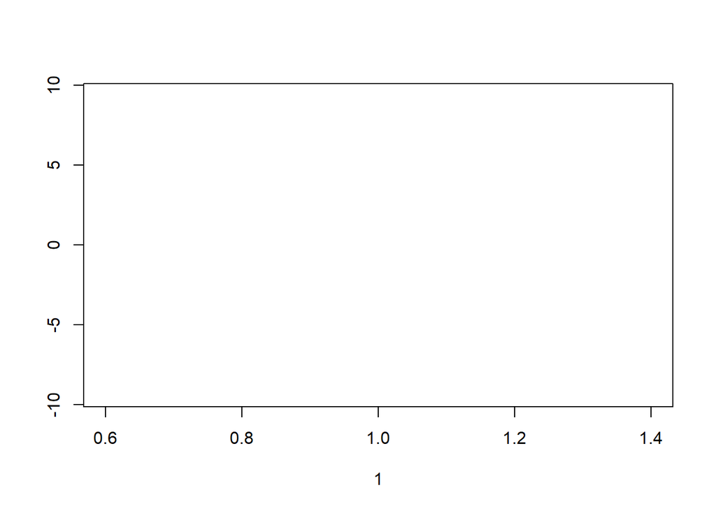

```r
plot(1, -9.361879, type = "l", xlim = c(1,1), ylim = c(-9.361879,  9.361879), ylab="")
```